# Project: Investigate a Dataset - Medical Appointment No Shows

- Introduction
- Data Wrangling
- Exploratory Data Analysis
- Conclusions

## Introduction

This project uses a dataset on medical appointment to investigate potential reasons for appointments that result in no-shows.

This data analysis will conducted in a Jupyter Notebook using a Python 3 kernel.

The questions I will attempt to answer by analysing this dataset include:

1. Are patients with a scholarship more or less likely to show up to an appointment?
2. Does a patient's age influence the likelihood that they'll show up to an appointment?

First, let's import the necessary libraries for this data analysis. We've also included a "magic word" command to ensure that plots are generated inline within this Jupyter Notebook:

```python
# imports
import numpy as np
import pandas as pd
import matplotlib.pyplot as plt
% matplotlib inline
import seaborn as sns
sns.set_style('darkgrid')
```

## Data Wrangling

### General Properties

Let's import the data sourced from [Kaggle](https://www.kaggle.com/joniarroba/noshowappointments).

```python
# Load your data and print out a few lines.
# Perform operations to inspect data types and look for instances of missing or possibly errant data.
df = pd.read_csv('noshowappointments-kagglev2-may-2016.csv')
```

As can be seen below, the dataset includes various information on the appointment (e.g. scheduled day) and on the patient (e.g. patient ID). The last column includes information on whether the patient showed up to the appointment ('No)' or not ('Yes').

```python
df.head()
```

|  | PatientId | AppointmentID | Gender | ScheduledDay | AppointmentDay | Age | Neighbourhood | Scholarship | Hipertension | Diabetes | Alcoholism | Handcap | SMS_received | No-show |
| --- | --- | --- | --- | --- | --- | --- | --- | --- | --- | --- | --- | --- | --- | --- |
| 0 | 2.987250e+13 | 5642903 | F | 2016-04-29T18:38:08Z | 2016-04-29T00:00:00Z | 62 | JARDIM DA PENHA | 0 | 1 | 0 | 0 | 0 | 0 | No |
| 1 | 5.589978e+14 | 5642503 | M | 2016-04-29T16:08:27Z | 2016-04-29T00:00:00Z | 56 | JARDIM DA PENHA | 0 | 0 | 0 | 0 | 0 | 0 | No |
| 2 | 4.262962e+12 | 5642549 | F | 2016-04-29T16:19:04Z | 2016-04-29T00:00:00Z | 62 | MATA DA PRAIA | 0 | 0 | 0 | 0 | 0 | 0 | No |
| 3 | 8.679512e+11 | 5642828 | F | 2016-04-29T17:29:31Z | 2016-04-29T00:00:00Z | 8 | PONTAL DE CAMBURI | 0 | 0 | 0 | 0 | 0 | 0 | No |
| 4 | 8.841186e+12 | 5642494 | F | 2016-04-29T16:07:23Z | 2016-04-29T00:00:00Z | 56 | JARDIM DA PENHA | 0 | 1 | 1 | 0 | 0 | 0 | No |

As shown below, the dataset does not include any missing data. All columns feature 110,527 entries.  
Datatypes for the columns include floats (e.g. PatientID), integers (e.g. Appointment ID) and 'objects'.

```python
df.info()
```

```
<class 'pandas.core.frame.DataFrame'>
RangeIndex: 110527 entries, 0 to 110526
Data columns (total 14 columns):
PatientId         110527 non-null float64
AppointmentID     110527 non-null int64
Gender            110527 non-null object
ScheduledDay      110527 non-null object
AppointmentDay    110527 non-null object
Age               110527 non-null int64
Neighbourhood     110527 non-null object
Scholarship       110527 non-null int64
Hipertension      110527 non-null int64
Diabetes          110527 non-null int64
Alcoholism        110527 non-null int64
Handcap           110527 non-null int64
SMS_received      110527 non-null int64
No-show           110527 non-null object
dtypes: float64(1), int64(8), object(5)
memory usage: 11.8+ MB
```

As shown below, the 'object' types in the dataset are actually strings.

```python
print("Gender type is {}".format(type(df['Gender'][0])))
print("ScheduledDay type is {}".format(type(df['ScheduledDay'][0])))
print("AppointmentDay type is {}".format(type(df['AppointmentDay'][0])))
print("Neighbourhood type is {}".format(type(df['Neighbourhood'][0])))
print("No-show type is {}".format(type(df['No-show'][0])))
```

```
Gender type is <class 'str'>
ScheduledDay type is <class 'str'>
AppointmentDay type is <class 'str'>
Neighbourhood type is <class 'str'>
No-show type is <class 'str'>
```

The ScheduledDay and AppointmentDay use the following format for dates, which we may need to manipulate at a later stage for our analysis.

```python
df['ScheduledDay'][0]
```

```
'2016-04-29T18:38:08Z'
```

```python
df['AppointmentDay'][0]
```

```
'2016-04-29T00:00:00Z'
```

### Data Cleaning

Let's check the data for duplicates.

```python
print("There are {} duplicates in this data set".format(sum(df.duplicated())))
```

```
There are 0 duplicates in this data set
```

Let's check for NULL value in the dataset.

```python
df.isnull().sum()
```

```
PatientId         0
AppointmentID     0
Gender            0
ScheduledDay      0
AppointmentDay    0
Age               0
Neighbourhood     0
Scholarship       0
Hipertension      0
Diabetes          0
Alcoholism        0
Handcap           0
SMS_received      0
No-show           0
dtype: int64
```

I suspect the dataset was cleaned by the team at Kaggle and/or by the Health Authority in Brazil.  
The dataset does not feature duplicates, and does not contain NULLS.

## Exploratory Data Analysis

### Research Question 1: Are patients with a scholarship more or less likely to show up to an appointment?

Let's plot the relationship between holding a scholarship and the percentage of patients that showed up to their appointement.

Let's work out how many patients with/without scholarships showed up/did not show up to their appoitnment (in absolute values then in percentages)

```python
patient_att = df.groupby(['Scholarship','No-show']).count()['PatientId']
patient_att
```

```
Scholarship  No-show
0            No         79925
             Yes        19741
1            No          8283
             Yes         2578
Name: PatientId, dtype: int64
```

For non-scholarship holders (%):

```python
no_scholar_perc = (patient_att[0]/sum(patient_att[0]))*100
no_scholar_perc
```

```
No-show
No     80.192844
Yes    19.807156
Name: PatientId, dtype: float64
```

For scholarship holders (%):

```python
scholar_perc = (patient_att[1]/sum(patient_att[1]))*100
scholar_perc
```

```
No-show
No     76.263696
Yes    23.736304
Name: PatientId, dtype: float64
```

We are now ready to build the data visualisation we will use to answer this research question.

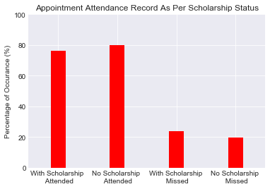

```python
x_axis = [1, 3, 5, 7]
plt.xlim(0, 8)
plt.ylim(0,100)
y_axis = [scholar_perc[0],no_scholar_perc[0], scholar_perc[1],no_scholar_perc[1]]
width = 0.5
plt.title('Appointment Attendance Record As Per Scholarship Status')
plt.ylabel('Percentage of Occurance (%)')
plt.bar(x_axis, y_axis, width, color="r");
x_labels = ['With Scholarship \n Attended', 'No Scholarship \n Attended', 'With Scholarship \n Missed', 'No Scholarship \n Missed']  # xtick labels
plt.xticks(x_axis, x_labels)
plt.legend();
```

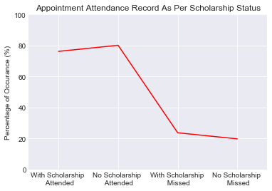

```python
x_axis = [1, 3, 5, 7]
plt.xlim(0, 8)
plt.ylim(0,100)
y_axis = [scholar_perc[0],no_scholar_perc[0], scholar_perc[1],no_scholar_perc[1]]
width = 0.5
plt.title('Appointment Attendance Record As Per Scholarship Status')
plt.ylabel('Percentage of Occurance (%)')
plt.plot(x_axis, y_axis,color="r");
x_labels = ['With Scholarship \n Attended', 'No Scholarship \n Attended', 'With Scholarship \n Missed', 'No Scholarship \n Missed']  # xtick labels
plt.xticks(x_axis, x_labels)
plt.legend();
```

### Response to Question 1

The data indicates that there is a non-negligible difference in attendance between non-scholarship holders and scholarship holders. Indeed, the percentage of scholarship holders that did NOT attend their appointment was 24% while the percentage of non-scholarship holders that did NOT attend their appointment was 20%. Hence, there is a 4% increase in the No-Show Up rate for scholarship holders compared to non-scholarship holders patients.

Since scholarship holders are from low socio-economic background, their lower attendance rate may be linked to lack of access to transportation / reliable infrastructure and other related hardships associated with their status.

### Research Question 2: Does a patient's age influence the likelihood that they'll show up to an appointment?

Let's plot the relationship between the age of the patient (by age groups) and the percentage of patients that showed up to their appointement.

```python
df_0_11 = df.query('0 < Age <= 11')
df_12_17 = df.query('12 < Age <= 17')
df_18_25 = df.query('18 < Age <= 25')
df_25_34 = df.query('25 < Age <= 34')
df_35_44 = df.query('35 < Age <= 44')
df_45_54 = df.query('45 < Age <= 54')
df_55_64 = df.query('55 < Age <= 64')
df_65_74 = df.query('65 < Age <= 74')
df_75_plus = df.query('Age > 75')
```

Then, let's then determine the percentages of patients who attend and do not attend for each age group.

```python
age_0_11 = (df_0_11.groupby(['No-show']).count()['PatientId'] / df.count()['Age']) * 100
age_0_11
```

```
No-show
No     11.769975
Yes     3.072552
Name: PatientId, dtype: float64
```

As shown above, the age_0_11 now holds information on the percentage of patients who attended and did not attend their appointments for the 0-11 age group. Let's do the same calculations for the other age groups.

```python
age_12_17 = (df_12_17.groupby(['No-show']).count()['PatientId'] / df.count()['Age']) * 100
age_18_25 = (df_18_25.groupby(['No-show']).count()['PatientId'] / df.count()['Age']) * 100
age_25_34 = (df_25_34.groupby(['No-show']).count()['PatientId'] / df.count()['Age']) * 100
age_35_44 = (df_35_44.groupby(['No-show']).count()['PatientId'] / df.count()['Age']) * 100
age_45_54 = (df_45_54.groupby(['No-show']).count()['PatientId'] / df.count()['Age']) * 100
age_55_64 = (df_55_64.groupby(['No-show']).count()['PatientId'] / df.count()['Age']) * 100
age_65_74 = (df_65_74.groupby(['No-show']).count()['PatientId'] / df.count()['Age']) * 100
age_75_plus = (df_75_plus.groupby(['No-show']).count()['PatientId'] / df.count()['Age']) * 100
```

We are now ready to plot the percentages of people who missed their appointments by age group.

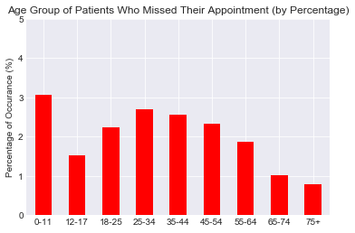

```python
x_axis = [1, 3, 5, 7, 9, 11, 13, 15, 17]
plt.xlim(0, 18)
plt.ylim(0,5)
y_axis = [age_0_11[1], age_12_17[1], age_18_25[1], age_25_34[1], age_35_44[1], age_45_54[1], age_55_64[1], age_65_74[1], age_75_plus[1]]
width = 1
plt.title('Age Group of Patients Who Missed Their Appointment (by Percentage)')
plt.ylabel('Percentage of Occurance (%)')
plt.bar(x_axis, y_axis, width, color="r");
x_labels = ['0-11', '12-17', '18-25', '25-34', '35-44', '45-54', '55-64', '65-74', '75+']  # xtick labels
plt.xticks(x_axis, x_labels)
plt.legend();
```

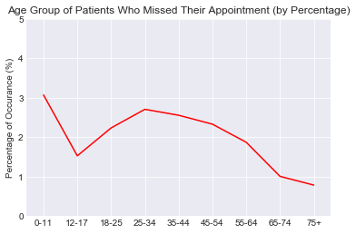

```python
x_axis = [1, 3, 5, 7, 9, 11, 13, 15, 17]
plt.xlim(0, 18)
plt.ylim(0,5)
y_axis = [age_0_11[1], age_12_17[1], age_18_25[1], age_25_34[1], age_35_44[1], age_45_54[1], age_55_64[1], age_65_74[1], age_75_plus[1]]
width = 1
plt.title('Age Group of Patients Who Missed Their Appointment (by Percentage)')
plt.ylabel('Percentage of Occurance (%)')
plt.plot(x_axis, y_axis, color="r");
x_labels = ['0-11', '12-17', '18-25', '25-34', '35-44', '45-54', '55-64', '65-74', '75+']  # xtick labels
plt.xticks(x_axis, x_labels)
plt.legend();
```

## Conclusion

The author of this report would like to note that all data analysis was directly applied to the dataset sourced from Kaggle. No predictive analysis or machine learning algorithms were part of this analysis.

No direct causations between patient data and their likelihood to miss or attend an appointment was derived in this report. This report only constitutes a preliminary exploration of the dataset.

Limitation of this data include the number and nature of the variables collected on the patient and the appointments. Also, there was no evaluation of the accuracy of the method(s) used for data collection.

Finally, future work include developing and applying predictive models to determine the likelihood of a patient showing up to a future appointment. A retro-active study can then look at the accuracy of the predictive models to validate (or not) the predictive algorithm(s).